# Quantum Errors

Rafael Peñaloza

2022-06-13

## Graphical Analysis

We start with some basic graphical analysis to understand the data.

### Error rate

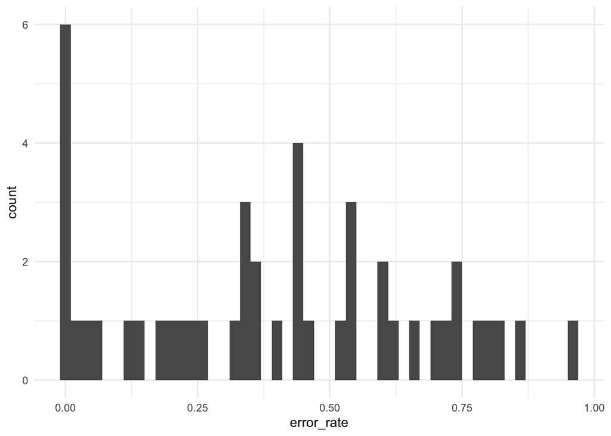

The error rate seems quite uniformly distributed. Given our small sample (only 45 cases), this has as **advantage** that we have examples for any error_rate we want, but the **disadvantage** is that we have only one example for most cases. The latter can later be fixed, by building appropriate examples from the hypotheses we generate.

### Depth

Let’s start from the obvious measure: does the *depth* influence the *error rate*?

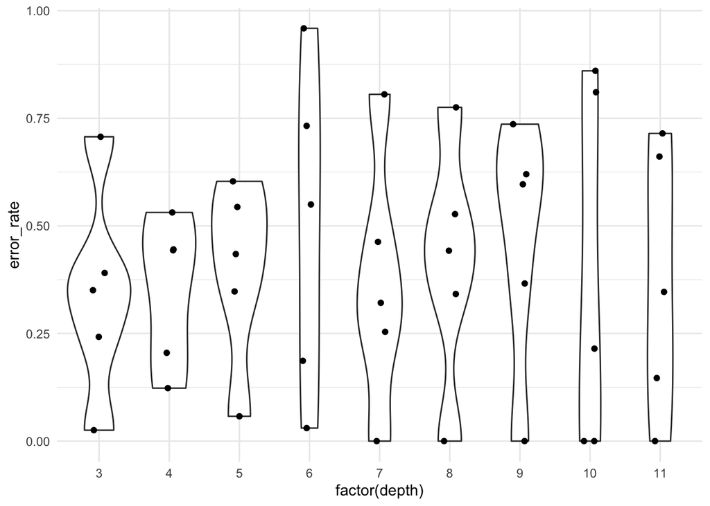

Visually, it doesn’t look like *depth* is a relevant factor. What about *qubits* and *clbits*?

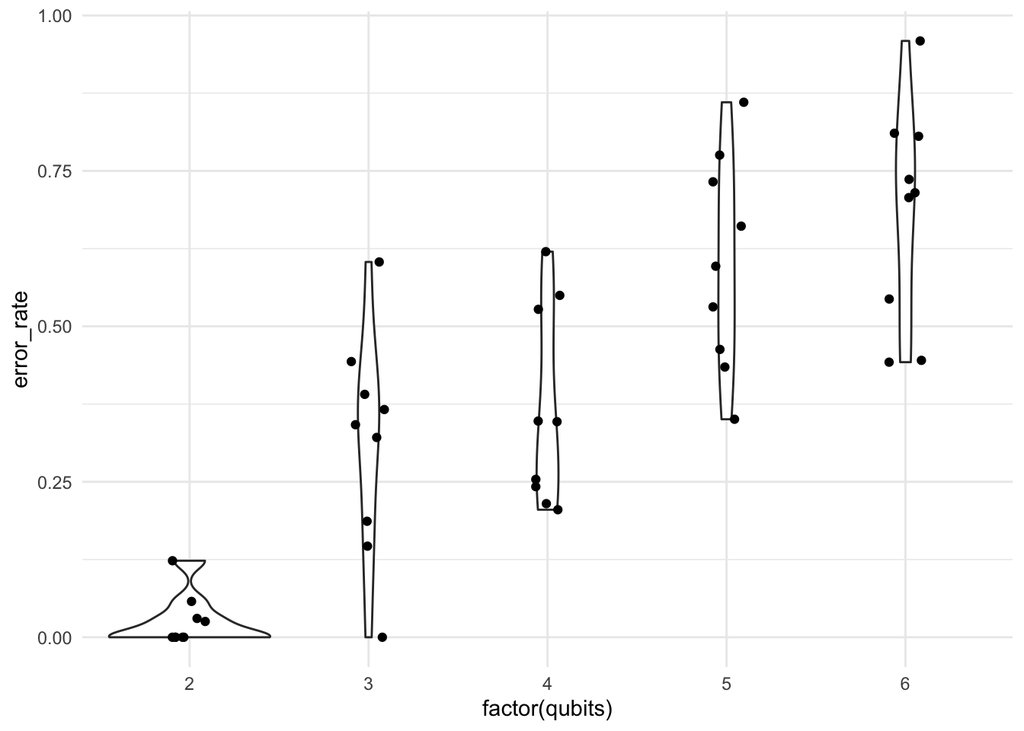

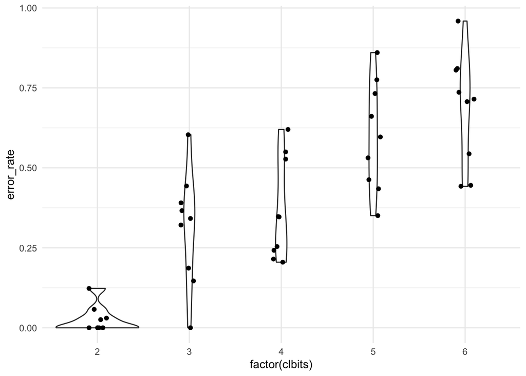

Here we start to see a difference (good!), but note that the data seems the same for *qubits* and *clbits*. Control:

```r
nrow(qdata[qdata$qubits != qdata$clbits, ])
```

```
## [1] 0
```

For now, we simply analyse in relation to *qubits*. A simple linear regression model seems adequate.

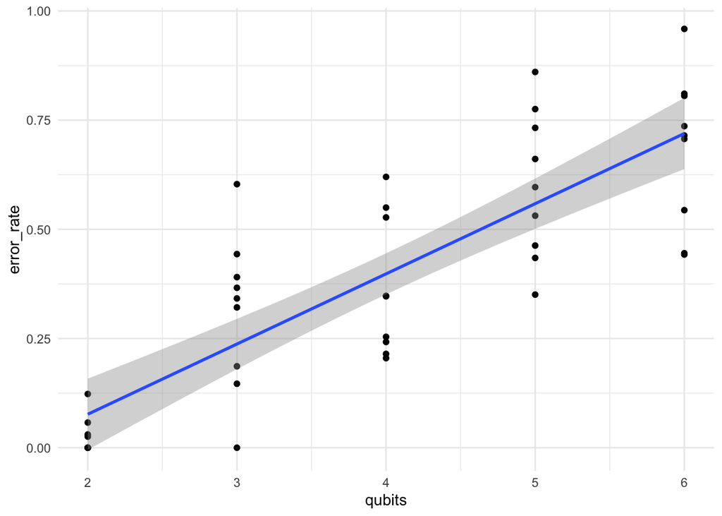

```r
lm_fit <- lm(error_rate ~ qubits, data=qdata)
summary(lm_fit)
```

```
##
## Call:
## lm(formula = error_rate ~ qubits, data = qdata)
##
## Residuals:
##      Min       1Q   Median       3Q      Max
## -0.27711 -0.09091 -0.02754  0.10441  0.36612
##
## Coefficients:
##             Estimate Std. Error t value Pr(>|t|)
## (Intercept)  -0.2447     0.0700  -3.496  0.00111 **
## qubits        0.1607     0.0165   9.740 1.91e-12 ***
## ---
## Signif. codes:  0 '***' 0.001 '**' 0.01 '*' 0.05 '.' 0.1 ' ' 1
##
## Residual standard error: 0.1565 on 43 degrees of freedom
## Multiple R-squared:  0.6881, Adjusted R-squared:  0.6808
## F-statistic: 94.86 on 1 and 43 DF,  p-value: 1.909e-12
```

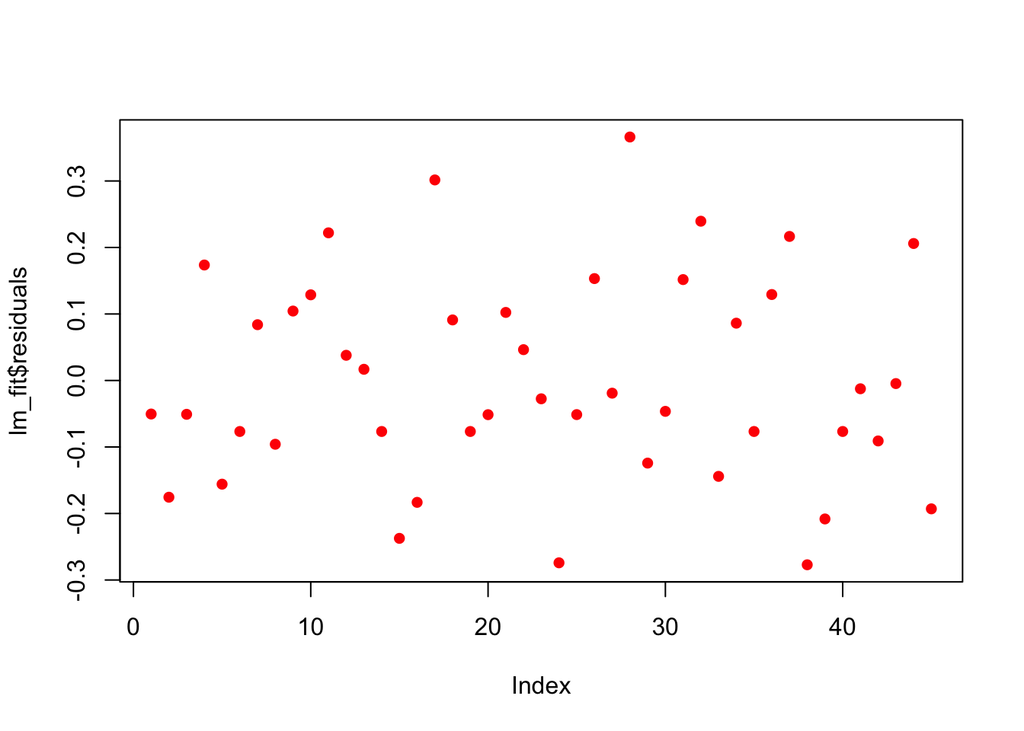

```r
plot(lm_fit$residuals, pch = 16, col = "red")
```

Indeed, the residuals do not have a pattern, but the R<sup>2</sup> is not very good: **0.6881001**. Still, there is wide variability, and we see that *qubits* is a good predictor for error. Other details may be necessary.